# RBIF112 Course Project

Author: Jonathan Hummel

Last update: 17 September, 2024

*Throughout this assignment, parts of the code presented below were modified from examples in the lecture notes provided throughout this course, as well as code from my past homework submissions.*

# **Data preparation**

For the sake of brevity, I will pick up where the course project instructions left off and will not include anything about the the code from sections 1 & 2 (Introduction & TCGA data). Instead, I saved 3 R objects produced by following the steps from those sections: `SECoding`,`dataFilt_Coding`, and `DEGsCoding`. These are the `summarizedExperiment` object created from the TCGA-BRCA data (226 tumor/normal samples, evenly split), the matrix of filtered and normalized FPKM values extracted from `SECoding`, and the data frame of differentially expressed genes (DEGs) from a limma analysis (tumor versus normal) of the filtered and normalized values, respectively (protein coding genes only). These 3 objects will simply be loaded and used for the data exploration and later steps, but it can be assumed that the code run to obtain them is the same as that of the instructions *with one exception*.

Instead of running these provided lines of code:

```r
dataNorm_Coding <- TCGAanalyze_Normalization(tabDF = dataPrep_Coding, geneInfo = geneInfoHT, method = "geneLength")
dataFilt_Coding <- TCGAanalyze_Filtering(tabDF = dataPrep_Coding, method = "quantile", qnt.cut =  0.25)
```

I ran these lines:

```r
dataNorm_Coding <- TCGAanalyze_Normalization(tabDF = dataPrep_Coding, geneInfo = geneInfoHT, method = "geneLength")
dataFilt_Coding <- TCGAanalyze_Filtering(tabDF = dataNorm_Coding, method = "quantile", qnt.cut =  0.25)
```

The difference in the second code chunk is that `dataFilt_Coding` is created by filtering the normalized data from `dataNorm_Coding`, rather than the values extracted from the `summarizedExperiment` into `dataPrep_Coding` (which were not normalized). This seemed more correct, as I wanted to be using normalized *and* filtered data (not one or the other). The resulting boxplots of the distributions of expression values for all samples seemed to confirm that this was a sound decision (not shown). Code like that of the first chunk above can be found in the `TCGAbiolinks` documentation. For example, the documentation for `TCGAanalyze_DEA()` has an example snippet at the bottom that does not filter the normalized data, but rather the original data, before passing the filtered output into `TCGAanalyze_DEA()`. That said, other `TCGAbiolinks` documentation, e.g. that of `TCGAanalyze_Filtering()`, has examples that follow what I think are the correct steps (see the end of that doc page). I was also able to find a protocol paper using `TCGAanalyze_Filtering()` and `TCGAanalyze_Normalization()` the way I chose to in the second snippet above (see steps 6 & 7 in the “Data preparation…” section by *Arshad and McDonald*) [1]. Anyways, all things considered, it seemed safe to proceed with the second chunk above, and the `dataFilt_Coding` and `DEGsCoding` objects loaded next are based on that change, with all else remaining the same.

# **Data exploration**

## Variable correlations

### Continuous & genes

I started by investigating whether there are genes correlated with any continuous patient variables. First I manually looked through `colData(SECoding)` to find continuous patient variables that did not seem totally trivial or empty. Then, after loading and preparing the saved objects discussed earlier, the code below loops through a vector of each interesting continuous variable name and then calculates the correlation coefficients (Spearman), p-values (`corr.test`), and adjusted p-values (BH/FDR) for all genes and the variable in question. All of these results are saved to a list of data frames, which also includes some helper functions for accessing information from the object. In the loop just described, both `cor()` and `cor.test()` were called with `use="pairwise.complete.obs"`, so that correlations were only calculated using the cases where values were present in both the expression and patient metadata for each variable. This was important, as quite a few variables in the patient data have missing values. The results from this loop are then displayed/investigated in several ways. The first of these is a volcano-like plot of the adjusted p-values versus the Spearman correlations for each continuous patient variable, with the points colored by density using `densCols()`. A function was written which facilitates creating and formatting these plots repeatedly for each continuous variable considered. While a bit odd, this type of volcano plot provided a more concise way to visualize and consider both the distribution of adjusted p-values and distribution of correlations at the same time, which was helpful for the interpretation of results. Lastly, a data frame summarizing much of the key information in the volcano-like plots was created and put into a `DT::datatable()` for consideration. Most notably, this table also includes the percentage of DEGs (determined in the intro steps) that were among the genes significantly correlated with each continuous variable, as well as the significance of the association of each variable with `sample_type` (via `t.test`). This info is also helpful for the interpretation and discussion of results. The code below to make the volcano plots and `data table are all pretty standard stuff that I have used and explained throughout assignments in this course, so I will not go into detail. One thing that *is* worth noting is that, for formatting reasons, the code chunk displayed directly below was not actually run when Knitting this Markdown file. Instead the code seen below is broken up and run in separate hidden chunks to generate the output. The only code not identical to what can be seen below is a chunk used to put the volcano plots into separate tabs in the markdown file, which a StackOverflow forum post helped me figure out [2].

```r
library("SummarizedExperiment")
library("DT")
library("reshape")


### Load TCGA-BRCA data (226 samples) prepared by following the preparatory steps
# in the course project instructions (saved to not have to repeat those steps)
# ONE CHANGE WAS MADE FROM THE COURSE PROJECT INSTRUCTIONS:
# TCGAanalyze_Filtering() takes output from TCGAanalyze_Normalization() (https://doi.org/10.1016/j.xpro.2022.101432)
load(file="SECoding.sv") # summarizedExperiment object including protein coding genes only
load(file="dataFilt_Coding.sv") # quantile normalized and filtered fpkm values
load(file="DEGsCoding.sv") # table of DEGs from a limma analysis of quantile normalized fpkm
patient.meta <- as.data.frame(colData(SECoding))
# Make sure the expression samples/columns are ordered the same as the patient data table
dataFilt_Coding <- dataFilt_Coding[,rownames(patient.meta)]


# Some handy function definitions

# Useful for getting/setting the lower triangle of a correlation matrix
get.tri=function(df) {df[lower.tri(df, diag = FALSE)]}

# Function to filter NAs from a vector
na.filter <- function(some.vector) {
  some.vector[!is.na(some.vector)]
}


### Gene correlation exploration: ###

## Which genes are associated with continuous data attributes (e.g. days to death, age, ect…)?
# Do any of these genes represent confounding variables in the data set?

# vector of non-empty continuous variables collated by looking through colData(SECoding)
# Some of these may be redundant or otherwise trivial but never hurts to check
contin.vars <- c("days_to_collection",
                 "initial_weight",
                 "days_to_last_follow_up",
                 "age_at_diagnosis",
                 "year_of_diagnosis",
                 "age_at_index",
                 "year_of_birth",
                 "days_to_death",
                 "year_of_death")

# Which genes are correlated with which of the variables above?

# prepare a list of data frames to hold the correlation coefficients and p-values
# this object also has functions to facilitate getting values and genes lists afterward
template.df <- as.data.frame(matrix(ncol=length(contin.vars), nrow=dim(dataFilt_Coding)[1]))
colnames(template.df) <- contin.vars
rownames(template.df) <- rownames(dataFilt_Coding)
gene.contin.assoc <- list(corr=template.df,
                          p.vals=template.df,
                          p.adj=template.df,
                          get.values=function(value, meta, corr.filter=0, fdr.filter=1) {na.filter(gene.contin.assoc[[value]][abs(gene.contin.assoc$corr[,meta])>=corr.filter & gene.contin.assoc$p.adj[,meta]<=fdr.filter, meta])},
                          get.genes=function(meta, corr.filter=0, fdr.filter=1) {rownames(gene.contin.assoc$corr)[na.filter(abs(gene.contin.assoc$corr[,meta])>=corr.filter & gene.contin.assoc$p.adj[,meta]<=fdr.filter)]})
# Loop through each continuous variable and calculate correlation with each gene and the associated p-values
for (i in 1:length(contin.vars)) {
  current.var <- patient.meta[,contin.vars[i]]
  # Get Spearman correlation coefficient for all genes with the current continuous variable
  gene.contin.assoc$corr[,contin.vars[i]] <- apply(dataFilt_Coding, MARGIN=1, function(expr) cor(expr, current.var, use="pairwise.complete.obs", method="spearman"))
  # Get p-value associated with Spearman correlation coefficient for all genes with the current continuous variable
  gene.contin.assoc$p.vals[,contin.vars[i]] <- apply(dataFilt_Coding, MARGIN=1, function(expr) cor.test(expr, current.var, use="pairwise.complete.obs", method="spearman", exact=FALSE)$p.value)
  gene.contin.assoc$p.adj[,contin.vars[i]] <- p.adjust(gene.contin.assoc$p.vals[,contin.vars[i]], method = "fdr")
}

# Function that makes a version of a volcano plot to consider correlation and significance at once.
make.volcano <- function(variable_name, FDR.cutoff) {
  x <- gene.contin.assoc$get.values("corr", variable_name)
  y <- gene.contin.assoc$get.values("p.adj", variable_name)
  plot(x, y,
       main=paste("Gene correlations with ", variable_name, "\n(", sum(is.na(patient.meta[,variable_name])), " missing values)", sep=""),
       xlab="Spearman correlation",
       ylab="p-adjusted",
       pch=19, col=densCols(x,y))
  txt.y <- max(na.filter(y))
  text(rep(min(na.filter(x)), 4),
       c(txt.y, txt.y-0.05, txt.y-0.1, txt.y-0.15),
       labels=c(paste("N sig. genes:", length(gene.contin.assoc$get.values("p.adj", variable_name, fdr.filter = FDR.cutoff))),
                paste("MEAN(abs(corr)):", round(mean(abs(gene.contin.assoc$get.values("corr", variable_name, fdr.filter = FDR.cutoff))), digits = 2)),
                paste("MAX(abs(corrs)):", round(max(abs(gene.contin.assoc$get.values("corr", variable_name, fdr.filter = FDR.cutoff))), digits = 2)),
                paste("% of DEGs overlap: ", round(100*sum(gene.contin.assoc$get.genes(variable_name, fdr.filter = FDR.cutoff) %in% rownames(DEGsCoding))/dim(DEGsCoding)[1]), "%", sep="")),
       pos=4)
  abline(v=0, lty=1, lwd=2)
  abline(h=FDR.cutoff, lty=3, lwd=1.5)
  legend(x="topright",
         legend = c(paste("FDR ≤ ", round(100*FDR.cutoff),"%", sep=""), "Densest", "Sparsest"),
         lty=c(3, NA, NA),
         lwd=c(1.5, NA, NA),
         pch=c(NA, 22, 22),
         col=rep("black", 3),
         pt.bg=c(NA, "#08306B", "#F7FBFF"))
}

# Summarize the gene correlations with continuous variables in a series of plots
# this loop was modified and run in a separate code chunk below to put each plot in a tab
# https://stackoverflow.com/questions/43636120/how-to-embed-plots-into-a-tab-in-rmarkdown-in-a-procedural-fashion
par(mfrow=c(5,2))
plots.list <- list()
for (i in 1:length(contin.vars)) {
  plots.list[[i]] <- make.volcano(contin.vars[i], 0.05)
}
par(mfrow=c(1,1))

# Prepare results for display as in a table
dt.cols <- c("Variable", "N.Corr (FDR ≤ 5%)", "Mean abs(corr)", "Min abs(corr)", "Max abs(corr)", "DEGs overlap %", "sample_type assoc. p", "N missing")
table.df <- as.data.frame(matrix(nrow=length(contin.vars), ncol=length(dt.cols)))
colnames(table.df) <- dt.cols
table.df$Variable <- contin.vars
table.df[,"sample_type assoc. p"] <- sapply(contin.vars, function(c.var) t.test(patient.meta[,c.var]~patient.meta$sample_type, na.action = "na.omit")$p.value)
table.df[,"sample_type assoc. p-adj"] <- p.adjust(table.df[,"sample_type assoc. p"], method="fdr")
for (i in 1:length(contin.vars)) {
  variable.name <- contin.vars[i]
  FDR.cutoff <- 0.05
  table.df[i,"N.Corr (FDR ≤ 5%)"] <- length(gene.contin.assoc$get.values("p.adj", variable.name, fdr.filter = FDR.cutoff))
  table.df[i,"Mean abs(corr)"] <- round(mean(abs(gene.contin.assoc$get.values("corr", variable.name, fdr.filter = FDR.cutoff))), digits = 2)
  table.df[i,"Min abs(corr)"] <- round(min(abs(gene.contin.assoc$get.values("corr", variable.name, fdr.filter = FDR.cutoff))), digits = 2)
  table.df[i,"Max abs(corr)"] <- round(max(abs(gene.contin.assoc$get.values("corr", variable.name, fdr.filter = FDR.cutoff))), digits = 2)
  table.df[i,"DEGs overlap %"] <- round(100*sum(gene.contin.assoc$get.genes(variable.name, fdr.filter = FDR.cutoff) %in% rownames(DEGsCoding))/dim(DEGsCoding)[1])
  table.df[i,"N missing"] <- sum(is.na(patient.meta[,variable.name]))
}

# Display the results into a DT::datatable
table.to.show <- table.df[order(table.df$`DEGs overlap %`, decreasing = TRUE), c("Variable", "N.Corr (FDR ≤ 5%)", "Mean abs(corr)", "Min abs(corr)", "Max abs(corr)", "DEGs overlap %", "sample_type assoc. p-adj", "N missing")]
table.to.show[,c("sample_type assoc. p-adj")] <- format(table.to.show[,c("sample_type assoc. p-adj")], digits = 2, scientific = TRUE)
datatable(table.to.show, caption = "Overview of gene correlations found among continuous patient variables (and variables' association with BRCA/sample_type)",
          rownames=FALSE, filter = 'none', options = list(pageLength = 10, scrollX = TRUE, scrollY = "400px", autoWidth = TRUE)) %>%
  formatStyle('Variable', target = 'row', backgroundColor = styleEqual(c("year_of_diagnosis", "days_to_collection"), c('pink', 'pink')))
```

#### Gene correlations w/ continuous variables (click a variable name to see plot)

##### days_to_collection

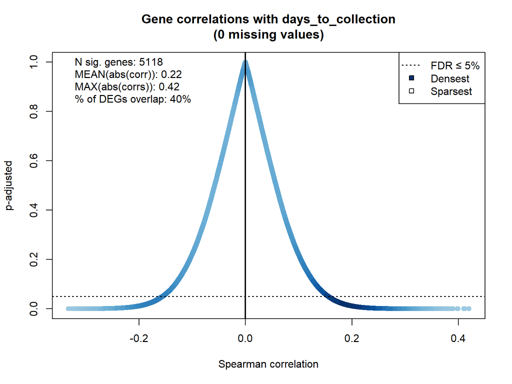

##### initial_weight

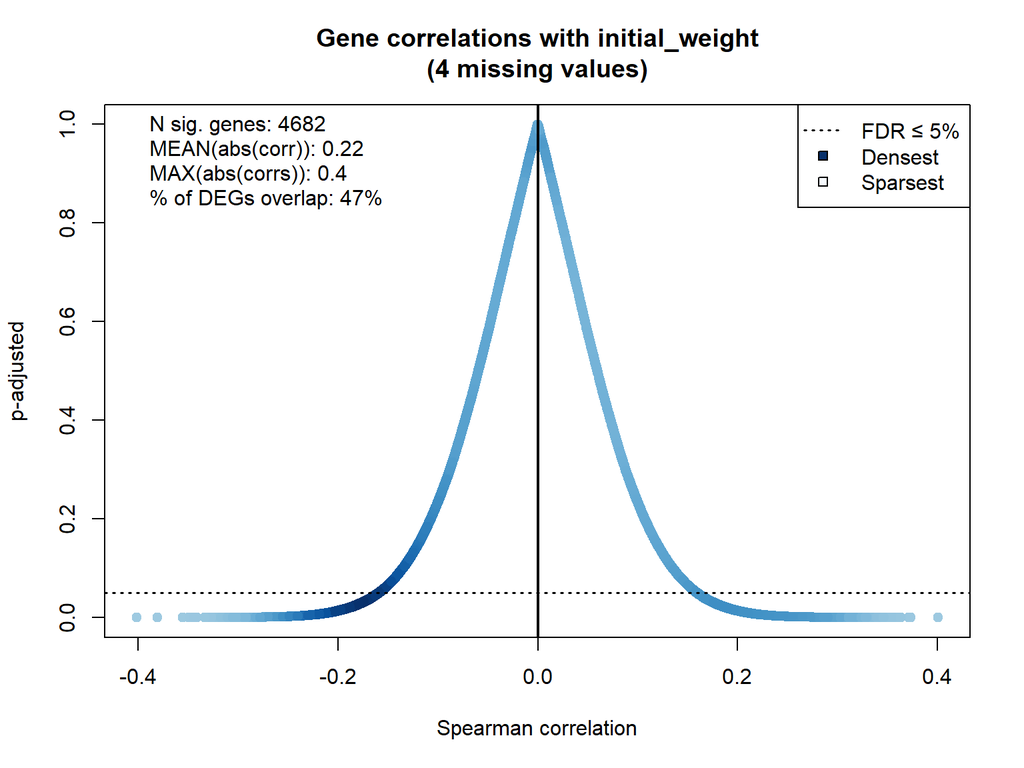

##### days_to_last_follow_up

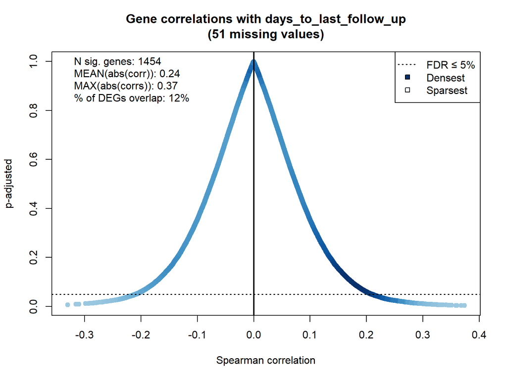

##### age_at_diagnosis

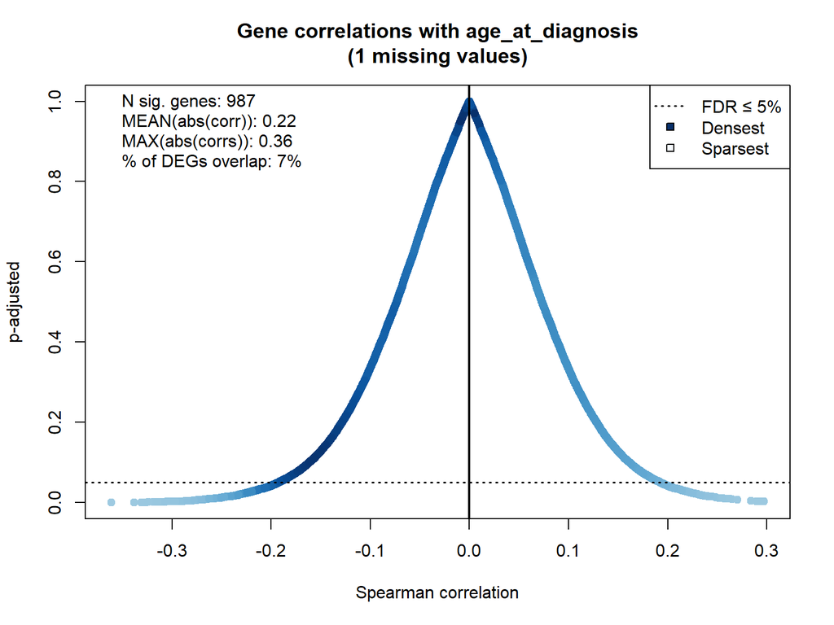

##### year_of_diagnosis

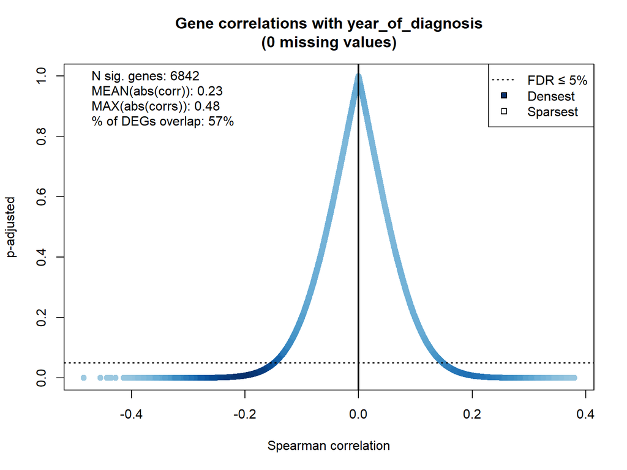

##### age_at_index

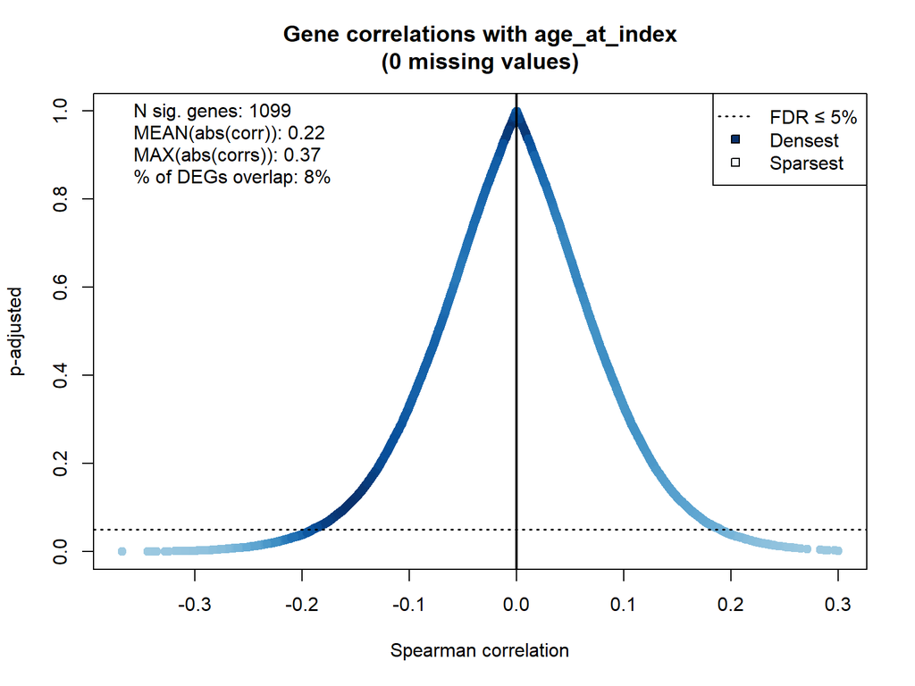

##### year_of_birth

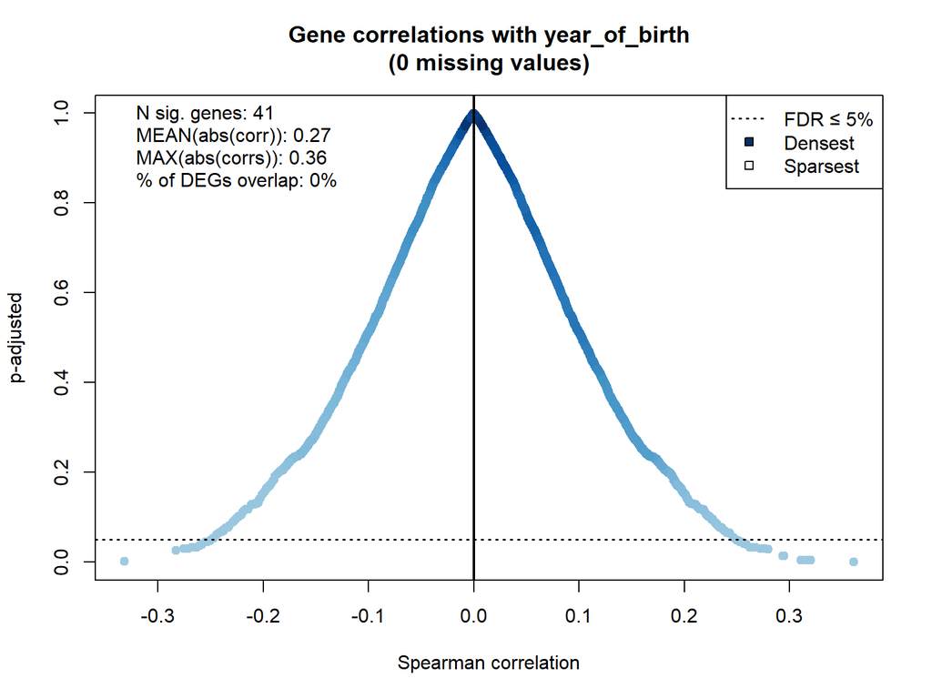

##### days_to_death

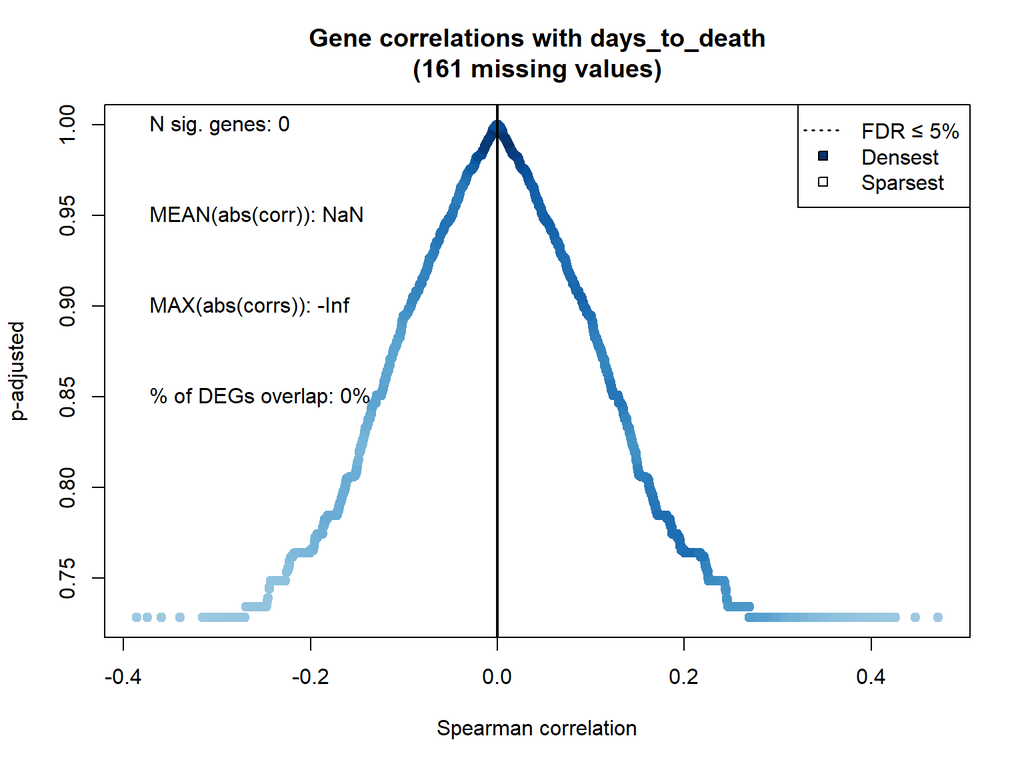

##### year_of_death

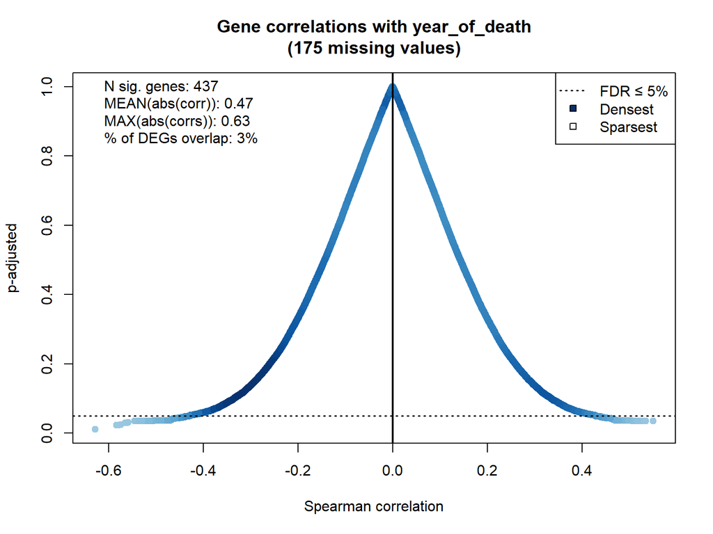

#### Table 1

| Variable | N.Corr (FDR ≤ 5%) | Mean abs(corr) | Min abs(corr) | Max abs(corr) | DEGs overlap % | sample_type assoc. p-adj | N missing |
| --- | --- | --- | --- | --- | --- | --- | --- |
| year_of_diagnosis | 6842 | 0.23 | 0.15 | 0.48 | 57 | 3.5e-05 | 0 |
| initial_weight | 4682 | 0.22 | 0.16 | 0.4 | 47 | 1.1e-01 | 4 |
| days_to_collection | 5118 | 0.22 | 0.16 | 0.42 | 40 | 5.4e-04 | 0 |
| days_to_last_follow_up | 1454 | 0.24 | 0.21 | 0.37 | 12 | 1.1e-01 | 51 |
| age_at_index | 1099 | 0.22 | 0.19 | 0.37 | 8 | 1.3e-01 | 0 |
| age_at_diagnosis | 987 | 0.22 | 0.19 | 0.36 | 7 | 1.3e-01 | 1 |
| year_of_death | 437 | 0.47 | 0.43 | 0.63 | 3 | 1.1e-01 | 175 |
| year_of_birth | 41 | 0.27 | 0.25 | 0.36 | 0 | 8.5e-01 | 0 |
| days_to_death | 0 |  |  |  | 0 | 7.8e-01 | 161 |

As seen by clicking through the plots above, all continuous variables other than `days_to_death` had at least some significantly correlated genes (FDR ≤ 5%). That said, it can be seen in the volcano plots that for most of these variables, the significantly correlated genes all had moderate to weak correlation strengths, with the most common values being on the weaker side. The only exception to this observation was `year_of_death`, which had a higher overall range of correlation (roughly 0.4 to 0.6), but the bulk of those genes were still on the moderate side and much fewer genes were correlated overall. These observations are all more obviously apparent in **Table 1**, which summarizes key stats from the distributions of correlation coefficients and adjusted p-values. Together the table and plots paint a general picture that quite a few genes are significantly correlated with most of these continuous variables, but these are largely weak or moderate correlations. This is better news than many strong and significant correlations, and the presence of many correlations is not particularly surprising given that 13304 genes were considered. The 2 variables of potential concern, highlighted in **Table 1**, are `year_of_diagnosis` and `days_to_collection`. These variables stand out because they are significantly associated with `sample_type` (tumor/normal) and their correlated genes constitute notable proportions of the DEGs (about 57% and 40%, respectively). The genes correlated with these 2 variables seem the most likely to represent confounding variables, because many correlate significantly (albeit weakly) with seemingly irrelevant information *and* with the outcome we are trying to predict: `sample_type` (i.e. tumor/normal). In short `year_of_diagnosis` and `days_to_collection` could correlate with both the independent (genes) and dependent (tissue type) variables in our model, depending on which genes are used. While correlation is not necessarily indicative of causation, this matters because, depending on why/how it happened, it *could* affect the accuracy and potential for generalization of the models built. As an extreme example, we could pick DEGs as predictors that only accidentally predicted disease status well in *this* specific data set due to unique systematic quirks/issues (that were actually driving the predictive ability of those genes). Setting aside a test/validation set cannot help with this type of problem, as that data would also carry the same systematic issue and also give an overly optimistic estimation of the model’s performance using the chosen genes, which would be entangled with the confounding variable(s). The good news is that the correlations of genes with these variables are largely weak, but it is worth looking at the specifics for the top 15 or so correlated DEGs, as these are the most likely to become predictive variables in the models built later. I may be wrong, but it is hard to imagine needing much more than 15 variables later for classification:

```r
## Checking out the top significance DEGs correlated with the 2 "interesting" variables above:
check.DEGs.continvar.corr <- function(variable) {
  df <- DEGsCoding[rownames(DEGsCoding) %in% gene.contin.assoc$get.genes(variable, fdr.filter = FDR.cutoff), c("logFC", "adj.P.Val")]
  df$Corr <- gene.contin.assoc$corr[rownames(df), variable]
  df$Cor.p.adj <- gene.contin.assoc$p.adj[rownames(df), variable]
  return(df)
}
# Top DEGs associated with year_of_diagnosis:
head(check.DEGs.continvar.corr("year_of_diagnosis"), n=15)
```

```
##                       logFC    adj.P.Val       Corr    Cor.p.adj
## ENSG00000136158  -17.982301 6.387554e-69 -0.2594243 5.186940e-04
## ENSG00000158966   -7.539823 5.485984e-68 -0.3485594 5.263571e-06
## ENSG00000187824   -3.646018 1.554373e-66 -0.3237183 1.916140e-05
## ENSG00000132561  -26.451327 3.448774e-65 -0.2264087 2.428781e-03
## ENSG00000198478  -12.132743 3.912561e-59 -0.2592196 5.236657e-04
## ENSG00000154065   -3.309735 1.125377e-57 -0.3194652 2.375041e-05
## ENSG00000177098   -7.929204 3.515685e-57 -0.2630609 4.313289e-04
## ENSG00000184500  -13.070796 2.097730e-56 -0.3042735 5.341216e-05
## ENSG00000154721   -8.778761 7.722334e-56 -0.2780953 2.020684e-04
## ENSG00000123096   -8.318584 1.522973e-55 -0.2781941 2.009354e-04
## ENSG00000152583 -190.486726 1.650483e-55 -0.2695017 3.140422e-04
## ENSG00000198947   -6.522124 2.648444e-54 -0.2710996 2.899708e-04
## ENSG00000173757  -15.752212 1.211879e-53 -0.2442673 1.070439e-03
## ENSG00000100154   -3.141593 1.211879e-53 -0.2689316 3.222451e-04
## ENSG00000070778   -4.238938 1.820884e-53 -0.2549171 6.395819e-04
```

```r
# Top DEGs associated with days_to_collection:
head(check.DEGs.continvar.corr("days_to_collection"), n=15)
```

```
##                       logFC    adj.P.Val      Corr    Cor.p.adj
## ENSG00000136158  -17.982301 6.387554e-69 0.2179738 0.0056310012
## ENSG00000158966   -7.539823 5.485984e-68 0.2874280 0.0003058543
## ENSG00000187824   -3.646018 1.554373e-66 0.2651136 0.0008076953
## ENSG00000198478  -12.132743 3.912561e-59 0.1835684 0.0200001749
## ENSG00000154065   -3.309735 1.125377e-57 0.2663254 0.0007674440
## ENSG00000177098   -7.929204 3.515685e-57 0.1971792 0.0122977623
## ENSG00000184500  -13.070796 2.097730e-56 0.2454229 0.0018685525
## ENSG00000154721   -8.778761 7.722334e-56 0.2242492 0.0044356319
## ENSG00000123096   -8.318584 1.522973e-55 0.2199269 0.0052660262
## ENSG00000152583 -190.486726 1.650483e-55 0.2083489 0.0081970758
## ENSG00000198947   -6.522124 2.648444e-54 0.1991158 0.0115072872
## ENSG00000173757  -15.752212 1.211879e-53 0.1662352 0.0356374432
## ENSG00000100154   -3.141593 1.211879e-53 0.2072760 0.0085174092
## ENSG00000070778   -4.238938 1.820884e-53 0.2019839 0.0104005657
## ENSG00000011523   -5.407080 4.177950e-53 0.2864107 0.0003204078
```

As seen above, the DEGs that had significant correlations with `year_of_diagnosis` or `days_to_collection` all had fairly weak correlations, which is better than the alternative. That said, it is interesting that for either variable, the direction of the correlations for all of the lowest p-adjusted DEGs are in the same direction and approximate strength (and opposite between these 2 variables). If I wanted to be careful and build a model that was possibly more protected against performing poorly with a brand new data set, I could choose to only include DEGs in the models that were not significantly correlated with either of these 2 variables (assuming some remained post-filtering that still had a low p-value, fold-change, etc. from limma). While this would not necessarily improve model performance during the testing phase in this assignment (it could actually hurt it, by omitting the lowest p-value DEGs from use), it would probably be best practice for a model that would be tested or used elsewhere. That said, I will only decide whether or not this seems worthwhile after the entire data exploration is done, as I may learn more about these variables later.

I am less concerned with the other variables, and their correlated genes, even though some of the genes are clearly among those that may be used as predictors in the modeling (i.e. DEGs). This is mainly because the correlations are weak on average and the variables involved are not additionally significantly associated with `sample_type` (i.e. the dependent variable). That said, it could still be problematic and worth investigating if a number of genes (especially DEGs) were strongly and significantly correlated with a variable that should be superfluous, as this could still represent some meaningful problem with the experiment/data depending on the context.

### Genes & genes

In the code below, the Spearman correlation coefficients between all pairwise combinations of filtered/normalized genes are first calculated using `cor()`. Then the corresponding pairwise p-values are calculated using `cor.test()` within a custom distance function and `proxy::dist()`. This was the most efficient implementation I could find, but calculating the matrix of p-values still took over 4 hours. Because of this, the objects from the first several steps below were saved and loaded in the code chunk actually run when knitting this Markdown file. Once again, the chunk below is for communication purposes only, and the actual code is run in separate hidden chunks afterward (which have those first few steps commented out, except for the load commands). After the distance object of `cor.test()` p-values was obtained, this was reshaped into a square matrix compatible with the correlation matrix (i.e. one with redundant values and a diagonal). From the lower triangle of that matrix, adjusted p-values were calculated (BH/FDR) and put into the lower triangle of another square matrix (the upper triangle of which was filled with the same information, and diagonals were set to 0). The matrices of correlation coefficients and corresponding adjusted p-values were then visualized in series of histograms for consideration on the basis of all genes, DEGs, and top DEGs (lower-triangle/non-diagonal values only). A function I wrote and used earlier to retrieve the values from the lower triangle of a matrix or data frame was useful in the code below (`get.tri()`). The histograms are created using pretty standard code (seen below) that I have used and explained throughout the course, so I will not go into detail here.

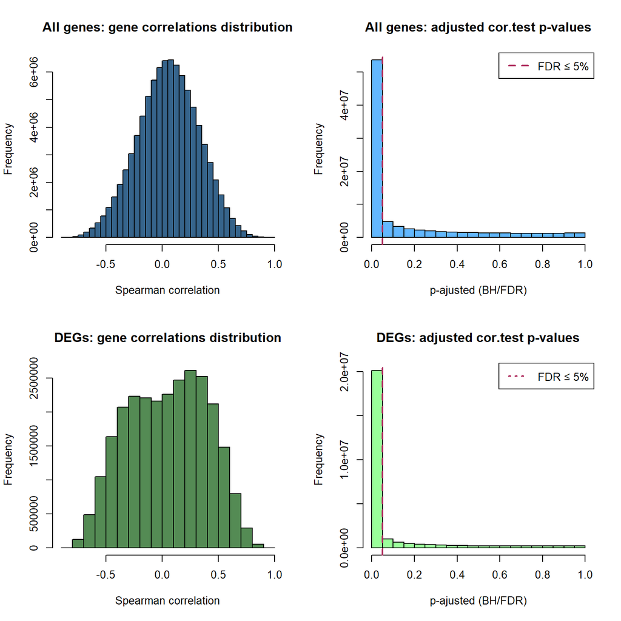

```r
## Which genes correlate with other genes? to what extent and significance?

## STEPS 1, 2, & 3 ARE JUST LOADED FROM A SAVE BECAUSE THEY TOOK A LONG TIME (PARTICULARLY 2)

# 1) Calculate the correlation matrix of correlations between all genes
gene.correlations <- cor(t(dataFilt_Coding), method = "spearman")
save(gene.correlations, file="gene.correlations.sv")
# load(file="gene.correlations.sv")

# 2) Calculate the corr.test (Spearman) p-values for each correlation
a <- Sys.time()
spearman.test <- function(x, y) {cor.test(x, y, method="spearman", exact=FALSE)$p.value}
gene.correlations.pvals <- proxy::dist(dataFilt_Coding, method = spearman.test)
save(gene.correlations.pvals, file="gene.correlations.pvals.sv")
b <- Sys.time()
b-a
# load(file="gene.correlations.pvals.sv")

# Convert distance object to matrix and reorder the rows/columns to agree with the other matrix
gene.correlations.pvals <- as.matrix(gene.correlations.pvals)
gene.correlations.pvals <- gene.correlations.pvals[rownames(gene.correlations), colnames(gene.correlations)]

# 3) Adjust the p-values calculated above, only for the lower triangle (exclude redundant pairs and self-comparisons)
gene.correlations.padj <- matrix(nrow=dim(dataFilt_Coding)[1], ncol=dim(dataFilt_Coding)[1])
rownames(gene.correlations.padj) <- rownames(gene.correlations)
colnames(gene.correlations.padj) <- colnames(gene.correlations)
gene.correlations.padj[lower.tri(gene.correlations.padj, diag = FALSE)] <- p.adjust(get.tri(gene.correlations.pvals), method="fdr")
save(gene.correlations.padj, file="gene.correlations.padj.sv")
# load(file="gene.correlations.padj.sv")

# Fill the upper triangle of gene.correlations.padj with the lower (for syntax convenience later)
gene.correlations.padj[upper.tri(gene.correlations.padj)] <- t(gene.correlations.padj)[upper.tri(t(gene.correlations.padj))]
diag(gene.correlations.padj) <- 0


## Visualize the results:

# Plot the distributions of correlations, all genes and among DEGs found in the intro steps
DEGs.corrs <- gene.correlations[rownames(DEGsCoding), rownames(DEGsCoding)]
DEGs.corrs.padj <- gene.correlations.padj[rownames(DEGsCoding), rownames(DEGsCoding)]
par(mfrow=c(2,2))
hist(get.tri(gene.correlations), main="All genes: gene correlations distribution", xlab="Spearman correlation", col="steelblue4")
hist(get.tri(gene.correlations.padj), main="All genes: adjusted cor.test p-values", xlab="p-ajusted (BH/FDR)", col="steelblue1")
abline(v=0.05, lty=2, lwd=2, col="maroon")
legend(x="topright", legend = c("FDR ≤ 5%"), lty=2, lwd=2, col="maroon")
hist(get.tri(DEGs.corrs), main="DEGs: gene correlations distribution", xlab="Spearman correlation", col="palegreen4")
hist(get.tri(DEGs.corrs.padj), main="DEGs: adjusted cor.test p-values", xlab="p-ajusted (BH/FDR)", col="palegreen1")
abline(v=0.05, lty=2, lwd=2, col="maroon")
legend(x="topright", legend = c("FDR ≤ 5%"), lty=3, lwd=2, col="maroon")
par(mfrow=c(1,1))

# Histogram of the sets of correlations that may be most relevant when model building
# aka the DEGs with significant corr.test p-values
sig.DEG.corrs.abs <- abs(get.tri(DEGs.corrs)[get.tri(DEGs.corrs.padj)<=0.05])
corr.min <- c(0.5, 0.6, 0.7, 0.8, 0.9, 0.95)
number.over <- sapply(corr.min, function(corr) sum(sig.DEG.corrs.abs>=corr))
hist(sig.DEG.corrs.abs, main="DEGs: distribution of significant correlation strengths (FDR ≤ 5%)", xlab="abs(Spearman)")
colz <- pals::glasbey(30)[5:(5+length(corr.min)-1)]
legend.items <- c()
for (i in 1:length(corr.min)) {
  abline(v=corr.min[i], lty=2, lwd=2, col=colz[i])
  legend.items[i] <- paste("Corr ≥ ", corr.min[i], " : ", number.over[i])
}
legend(x="left", legend = legend.items, lty=2, lwd=2, col=colz)

# Histogram of significant (FDR ≤ 5%) correlations among top 20 DEGs
top.DEGs.cor <- abs(get.tri(DEGs.corrs[rownames(DEGsCoding)[1:20], rownames(DEGsCoding)[1:20]])[get.tri(DEGs.corrs.padj[rownames(DEGsCoding)[1:20], rownames(DEGsCoding)[1:20]])<=0.05])
hist(top.DEGs.cor, main="Distribution of significant correlation strengths among top 20 DEGs", xlab="abs(Spearman)", col="palegreen")
```

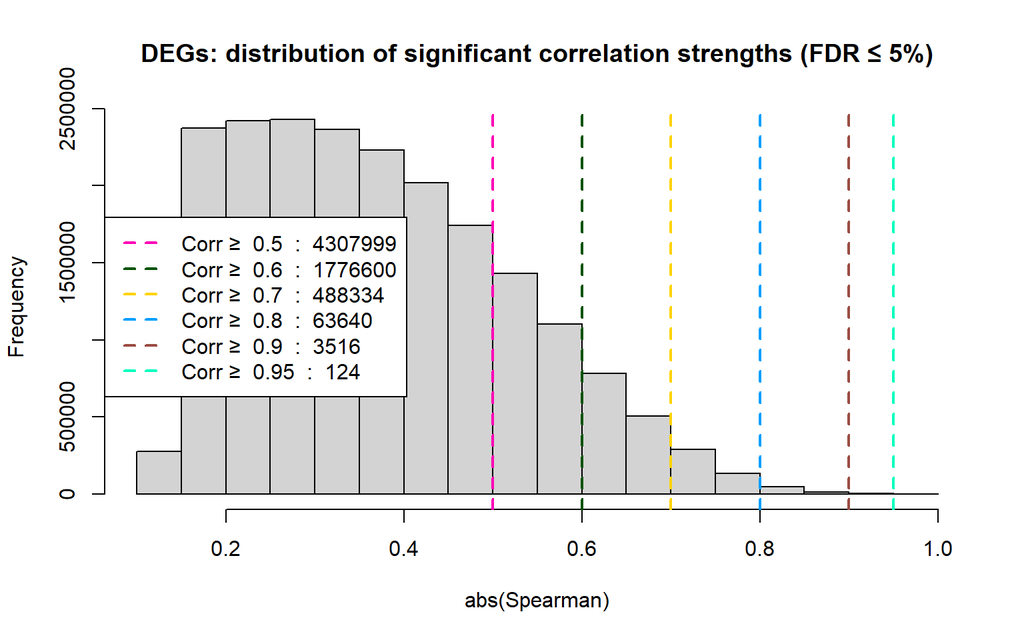

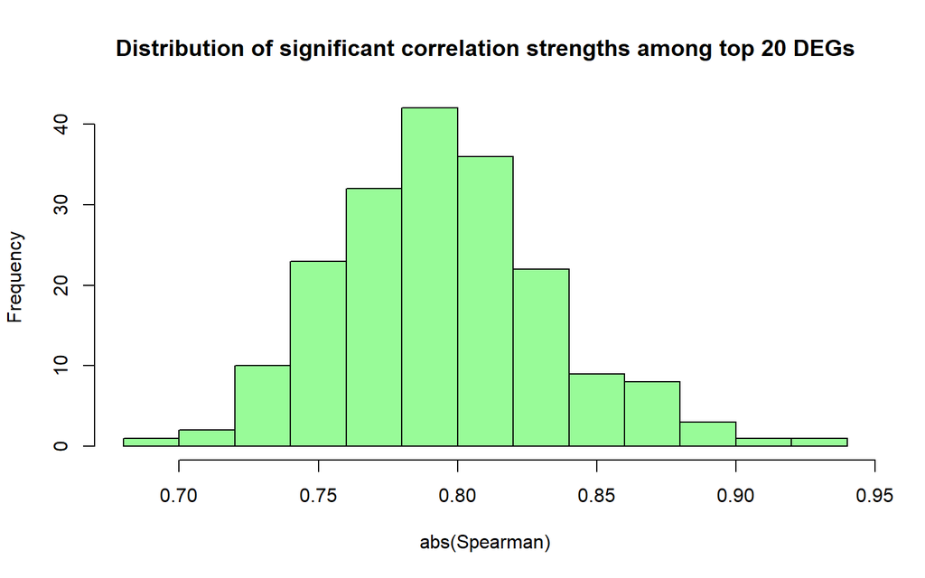

As seen in the first histogram above, while most significant correlations between DEGs are moderate to weak, there are still an immense number of moderate to strong correlations. Even just focusing on the strongest ones, there as many as ~3500 pairs of DEGs with significant correlations ≥ 0.9! What about the top 20 DEGs (by adjusted DEA p-value)? The second histogram shows that on average the top 20 DEGs are significantly and strongly correlated to one another. There are only 190 unique, non-self pairs among the top 20 DEGs, most of which appear to be accounted for by the distribution above. The histogram directly above is the most relevant finding from this part of the exploration, as these genes are the most likely to make their way into the models I will be building. The fact that relatively strong significant correlations between these genes is pretty much a guarantee will need to be kept in mind, because some models like logistic regression do not perform well with too many of such variables included. That said, given the histograms above, it seems as though it may be impossible to use any number of the most compelling DEGs *and* avoid including notably correlated predictive variables at the same time.

### Continuous & categorical

As for correlations between patient metadata features, I decided to first look at associations between all combinations of one continuous and one categorical variable. The continuous variables considered below are the same manually-picked ones from the *Continuous & Genes* section earlier. The categorical variables were gathered similarly by manually looking through the patient metadata table (i.e. `colData(SECoding)`) and recording the names of categorical columns without too many missing or trivial entries. Some of these variables may have admittedly been trivial or redundant to include, but I have limited understanding about the context of some of them. After defining this vector of categorical variables, much like earlier, a list of data frames is first constructed. The data frames have categorical variables as columns and continuous ones as rows and hold p-values and adjusted p-values (as well as counts of missing values per comparison). Next, a loop iterates through the combinations of these variables and calculates the significance of the association, but only where enough data exists in both variables (there is very limited coverage for some combinations). Unlike earlier for correlations with genes, below I used ANOVA on linear models of each continuous variable as a function of each categorical variable to calculate the p-values, because I could not calculate a correlation involving a categorical variable. While not necessarily ideal, I needed to take this approach because some of the categorical variables have more than two levels. Admittedly, I did not closely supervise the levels assigned for each categorical variable, so some levels captured in the models may have been nonsense. Nevertheless, this approach of ANOVA on linear models allowed for an easy way to quickly look for possible associations between all combinations of these variables. The adjusted p-values are finally calculated from the ANOVA p-values (BH/FDH). Only a histogram of the raw p-values was plotted, as the method just described produced no correlation coefficients (or intuitive stand-ins) to show. A `DT::datatable` was also made summarizing the significant associations found after multiple testing correction was applied. None of the visualization or table code is anything new, so I will not go into further detail.

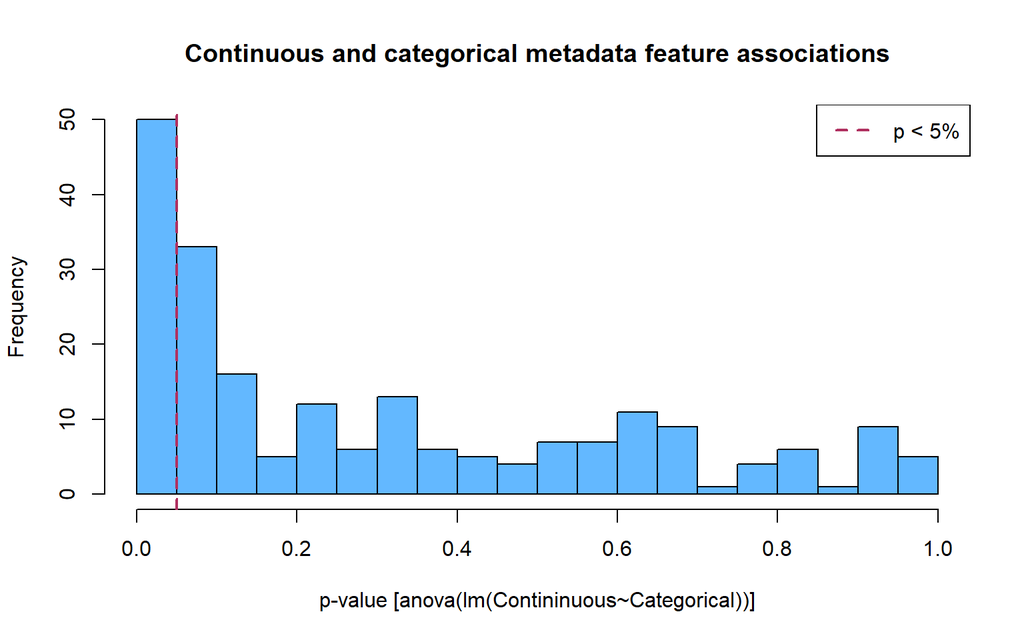

```r
# Categorical and continuous next

# vector of non-empty CATEGORICAL variables collated by looking through colData(SECoding)
# Some of these may be redundant or otherwise trivial but never hurts to check
cat.vars <- c("sample_type",
              "preservation_method",
              "oct_embedded",
              "is_ffpe",
              "synchronous_malignancy",
              "ajcc_pathologic_stage",
              "tissue_or_organ_of_origin",
              "primary_diagnosis",
              "prior_malignancy",
              "prior_treatment",
              "ajcc_staging_system_edition",
              "ajcc_pathologic_t",
              "ajcc_pathologic_n",
              "ajcc_pathologic_m",
              "morphology",
              "icd_10_code",
              "site_of_resection_or_biopsy",
              "race",
              "gender",
              "ethnicity",
              "vital_status",
              "paper_pathologic_stage",
              "paper_BRCA_Pathology",
              "paper_BRCA_Subtype_PAM50")

# prepare a list of data frames to hold the correlation coefficients and p-values
# this object also has functions to facilitate getting values and genes lists afterward
template.df <- as.data.frame(matrix(ncol=length(cat.vars), nrow=length(contin.vars)))
colnames(template.df) <- cat.vars
rownames(template.df) <- contin.vars
contin.cat.var.correlations <- list(p.vals=template.df,
                                    p.adj=template.df,
                                    n.incomplete=template.df)
# Loop through all combinations of categorical and continuous metadata features
# ANOVA of linear model is used to calculate p-values between variables (some have multi-levels)
for (i in 1:length(cat.vars)) {
  var.i <- patient.meta[,cat.vars[i]]
  for (j in 1:length(contin.vars)) {
    var.j <- patient.meta[,contin.vars[j]]
    # Calculate the correlation and p-value only if there are enough complete observations
    incomplete <- is.na(var.i) | is.na(var.j)
    levels.left <- length(table(var.i[!incomplete]))
    if (sum(!incomplete)!=0 & levels.left > 1) {
      contin.cat.var.correlations[["p.vals"]][j,i] <- anova(lm(var.j~var.i, na.action = "na.omit"))$`Pr(>F)`[1]
    }
    contin.cat.var.correlations[["n.incomplete"]][j,i] <- sum(incomplete) # track incomplete per pair of features
  }
}

# Adjust the p-values calculated above, only for the lower triangle (exclude redundant pairs and self-comparisons)
contin.cat.var.correlations$p.adj[,] <- as.matrix(p.adjust(as.vector(as.matrix(contin.cat.var.correlations$p.vals)), method="fdr"))

# Investigate the overall distribution of correlations between metadata features (strength and significance)
hist(as.vector(as.matrix(contin.cat.var.correlations$p.vals)), main="Continuous and categorical metadata feature associations", xlab="p-value [anova(lm(Contininuous~Categorical))]", breaks=25, col="steelblue1")
abline(v=0.05, lty=2, lwd=2, col="maroon")
legend(x="topright", legend = c("p < 5%"), lty=2, lwd=2, col="maroon")

# Make a table to explore in more detail the significant correlations between features
sig.correlations <- contin.cat.var.correlations$p.adj<=0.05 & !is.na(contin.cat.var.correlations$p.adj)
dt.cols <- c("Var1", "Var2", "p-adjusted", "Incomplete Obs.")
table.df <- as.data.frame(matrix(nrow=sum(sig.correlations), ncol=length(dt.cols)))
colnames(table.df) <- dt.cols
table.df[,"p-adjusted"] <- contin.cat.var.correlations$p.adj[sig.correlations]
pairs <- as.data.frame(as.table(sig.correlations), stringsAsFactors=FALSE)
table.df[,c("Var1", "Var2")] <- pairs[pairs$Freq==TRUE, 1:2]
table.df[,"Incomplete Obs."] <- sapply(1:dim(table.df)[1], function(i) contin.cat.var.correlations$n.incomplete[table.df[i,"Var1"], table.df[i,"Var2"]])

# Put the results into a datatable
table.to.show <- table.df[order(table.df$"p-adjusted"),]
table.to.show[,c("p-adjusted")] <- format(table.to.show[,c("p-adjusted")], digits = 2, scientific = TRUE)
datatable(table.to.show, caption = "Overview of signficant associations between continuous and categorical features (FDR ≤ 5%)",
          rownames=FALSE, filter = 'top', options = list(pageLength = 10, scrollX = FALSE, scrollY = "375px", autoWidth = TRUE))
```

#### Table 2

| Var1 | Var2 | p-adjusted | Incomplete Obs. |
| --- | --- | --- | --- |
| year_of_diagnosis | ajcc_staging_system_edition | 2.6e-74 | 43 |
| days_to_collection | ajcc_staging_system_edition | 3.8e-71 | 43 |
| days_to_collection | vital_status | 6.1e-30 | 0 |
| year_of_diagnosis | vital_status | 1.0e-26 | 0 |
| days_to_last_follow_up | ajcc_staging_system_edition | 9.4e-14 | 88 |
| days_to_collection | ajcc_pathologic_n | 2.3e-13 | 0 |
| year_of_diagnosis | ajcc_pathologic_n | 4.3e-12 | 0 |
| year_of_birth | vital_status | 1.7e-05 | 0 |
| year_of_diagnosis | sample_type | 9.0e-05 | 0 |
| year_of_birth | ajcc_staging_system_edition | 4.2e-04 | 43 |

[output cut: 14 more lines]

As seen in the histogram above, there definitely appear to be some correlations between continuous and categorical patient metadata features, as the distribution very roughly follows that same familiar shape of two superimposed distributions (i.e. the null and one enriched with low p-values). There are number of significant associations even after multiple testing corrections, which can be seen in **Table 2** above. While I will not pretend to understand the experimental/logistical context of every feature, quite a few of the significant associations above are clearly trivial. For example, I think `year_of_diagnosis` and `ajcc_staging_system_edition` simply reflects the fact that systems of pathological classification are updated as time moves on. Similarly, I think `vital_status` and `days_to_collection` makes perfect sense, as I imagine samples from the deceased need to be collected more quickly. There are so many other pairs that make sense in this way once a little thought is given, e.g. `vital_status` and `year_of_birth`, and so I will not go into all of them. Other pairs, while still not particularly interesting, may reveal some systematic “peculiarities” of the study. For example, it appears there is a bit of a systematic imbalance between samples collected from deceased versus live individuals (or even tumor versus normal samples) and the year of diagnosis. It is also worth noting that for some of these comparisons quite a bit of the data was incomplete, i.e. for many cases at least one of the two variables was missing. Much less trivially, but still not surprisingly, there is a significant association between `days_to_death` and `primary_diagnosis`, although over half of the cases were incomplete. It is worth noting that `sample_type` (the dependent/predicted variable later) was included among the categorical variables. This variable was only significantly associated with `year_of_diagnosis` and `days_to_collection`, which is consistent with the findings in the *Continuous & Genes* section earlier. I will be revisiting these variables in the next section. Overall, there was nothing to new or exciting in these results, at least based on my limited understanding. Many of the strongest associations are very trivial or relatively easy to explain, in that they represent basic facts of life or logistical aspects of the study, respectively. Other associations represent certain (possibly less trivial) imperfections, imbalances, or quirks of the study, but none of these seem to be particularly shocking or a cause for concern. Nonetheless, such an exploration is important because significant associations unearthed always have the chance of representing major issues with the study, and thus the data set. Every experiment from which predictive models are built is full of associations like the ones above, some of which could matter and effect the reproducibillity of the model’s demonstrated performance.

### Continuous & continuous

Next, I decided to look at the correlations between just the continuous variables (same ones considered above). This was done in the code below in a very similar way to how the Spearman correlation and corresponding p-values between all genes and these variables were computed, organized, and displayed earlier in the *Continuous & Genes* section. As such, I will not go into detail on the code below other than saying that at the heart of it is another loop using `cor()` and `cor.test()` for all pairwise combinations of variables. Like earlier, the results were put into a “volcano-like” plot of adjusted p-value versus Spearman correlation, as well as a `DT::datatable`, for consideration of the significant associations (using modified but familiar code from earlier).

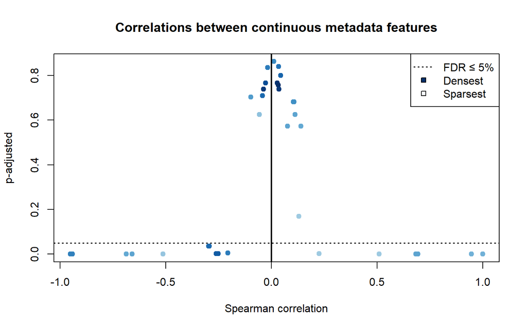

```r
## Which meta data features correlate with each other?
#(I will look at categorical and continuous variables)

# Continuous versus continuous first:

# prepare a list of data frames to hold the correlation coefficients and p-values
# this object also has functions to facilitate getting values and genes lists afterward
template.df <- as.data.frame(matrix(ncol=length(contin.vars), nrow=length(contin.vars)))
colnames(template.df) <- contin.vars
rownames(template.df) <- contin.vars
contin.var.correlations <- list(corr=template.df,
                                p.vals=template.df,
                                p.adj=template.df,
                                n.incomplete=template.df)
# Loop through all combinations of all non-empty continuous patient metadata features
# calculating the correlation and p-value along the way (Spearman) when enough data
for (i in 1:length(contin.vars)) {
    var.i <- patient.meta[,contin.vars[i]]
    for (j in 1:length(contin.vars)) {
    var.j <- patient.meta[,contin.vars[j]]
    # Calculate the correlation and p-value only if there are enough complete observations
    incomplete <- is.na(var.i) | is.na(var.j)
    if (sum(!incomplete)!=0) {
      contin.var.correlations[["corr"]][i,j] <- cor(var.i, var.j, use="pairwise.complete.obs", method="spearman")
      contin.var.correlations[["p.vals"]][i,j] <- cor.test(var.i, var.j, use="pairwise.complete.obs", method="spearman", exact=FALSE)$p.value
    }
    contin.var.correlations[["n.incomplete"]][i,j] <- sum(incomplete) # track incomplete per pair of features
  }
}

# Adjust the p-values calculated above, only for the lower triangle (exclude redundant pairs and self-comparisons)
contin.var.correlations$p.adj[lower.tri(contin.var.correlations$p.adj, diag = FALSE)] <- p.adjust(get.tri(contin.var.correlations$p.vals), method="fdr")

# Investigate the overall distribution of correlations between continuous metadata features (strength and significance)
x <- get.tri(contin.var.correlations$corr)
y <- get.tri(contin.var.correlations$p.adj)
plot(x, y,
     main="Correlations between continuous metadata features",
     xlab="Spearman correlation",
     ylab="p-adjusted",
     pch=19, col=densCols(x,y))
abline(v=0, lty=1, lwd=2)
abline(h=0.05, lty=3, lwd=1.5)
legend(x="topright",
       legend = c(paste("FDR ≤ 5%", sep=""), "Densest", "Sparsest"),
       lty=c(3, NA, NA),
       lwd=c(1.5, NA, NA),
       pch=c(NA, 22, 22),
       col=rep("black", 3),
       pt.bg=c(NA, "#08306B", "#F7FBFF"))

# Make a table to explore in more detail the significant correlations between features
sig.correlations <- contin.var.correlations$p.adj<=0.05 & !is.na(contin.var.correlations$p.adj)
dt.cols <- c("Var1", "Var2", "p-adjusted", "Spearman", "Incomplete Obs.")
table.df <- as.data.frame(matrix(nrow=sum(sig.correlations), ncol=length(dt.cols)))
colnames(table.df) <- dt.cols
table.df[,"p-adjusted"] <- contin.var.correlations$p.adj[sig.correlations]
table.df[,"Spearman"] <- round(contin.var.correlations$corr[sig.correlations], digits = 3)
table.df[,"Incomplete Obs."] <- contin.var.correlations$n.incomplete[sig.correlations]
pairs <- as.data.frame(as.table(sig.correlations), stringsAsFactors=FALSE)
table.df[,c("Var1", "Var2")] <- pairs[pairs$Freq==TRUE, 1:2]

# Put the results into a datatable
table.to.show <- table.df[order(table.df$"p-adjusted"),]
table.to.show[,c("p-adjusted")] <- format(table.to.show[,c("p-adjusted")], digits = 2, scientific = TRUE)
datatable(table.to.show, caption = "Overview of signficant correlations between continuous patient metadata features (FDR ≤ 5%)",
          rownames=FALSE, filter = 'top', options = list(pageLength = 10, scrollX = FALSE, scrollY = "375px", autoWidth = TRUE))
```

#### Table 3

| Var1 | Var2 | p-adjusted | Spearman | Incomplete Obs. |
| --- | --- | --- | --- | --- |
| age_at_index | age_at_diagnosis | 0.0e+00 | 1 | 1 |
| year_of_birth | age_at_index | 2.8e-115 | -0.951 | 0 |
| year_of_birth | age_at_diagnosis | 9.2e-114 | -0.95 | 1 |
| year_of_diagnosis | days_to_collection | 4.2e-107 | -0.942 | 0 |
| days_to_last_follow_up | days_to_collection | 1.4e-25 | 0.694 | 51 |
| year_of_diagnosis | days_to_last_follow_up | 2.1e-22 | -0.659 | 51 |
| year_of_death | days_to_collection | 1.3e-07 | -0.687 | 175 |
| year_of_death | year_of_diagnosis | 1.5e-07 | 0.683 | 175 |
| days_to_death | days_to_last_follow_up | 1.2e-06 | 0.946 | 212 |
| days_to_death | year_of_diagnosis | 4.3e-05 | -0.513 | 161 |

[output cut: 7 more lines]

As seen in the volcano plot above, most pairs of correlations between continuous patient metadata features are neither significant nor strong. That said, there are some significant correlations and of those a few are quite strong. **Table 3** holds the details on the significant correlations. Much like earlier in the associations between continuous and categorical variables, many of the significant correlations above seem to be trivial. This especially applies for the top 3 pairs seen above, which are essentially pairs of variables expressing the same information in different ways (which is why they correlate nearly perfectly). I was at first interested and surprised to see that `year_of_diagnosis` and `days_to_collection` correlated significantly and strongly (inversely), mainly because these were the variables found earlier to significantly correlate with both the dependent variable of interest (`sample_type` or comparable) and quite a few of the DEGs, including those with the lowest p-values (weak correlations on average). These 2 variables’ negative correlation with each other is consistent with the fact that each was correlated with the top 20 DEGs with consistently opposite signs (similar strengths). This pair probably simply reflects the fact that samples were collected within a much narrower time window toward the end of the full range of diagnosis dates for those samples. In that scenario, the collection date could be thought of as roughly constant, so as the year of diagnosis increases, the amount of time until collection decreases about perfectly linearly. This is a pretty trivial connection after all! Looking through the rest of the list, I do not see any correlations than could not be explained in a similarly trivial way. Perhaps the only pair that reflects some biology, albeit still within the realm of common knowledge, is the weak significant inverse correlation between `age_at_diagnosis` (or `age_at_index`, which seems to be the same thing) and `days_to_death`. While correlation does not necessarily indicate causation, older individuals are probably at least a little bit more likely to succumb earlier to a dangerous and taxing disease like cancer. A notable amount of data is missing for many of the pairs above, but if it were available, I imagine it may make the triviality of more of these correlations clearer (by their strength and nearly perfect correlation, as with the top pairs).

Overall, there is nothing too interesting or disconcerting about the results above with regards to our ability to use this data set to make a decent predictive model. In fact, I have come to realize that the two possible confounding variables discussed in the previous two sections are firmly related to each other in an obviously trivial way. Thinking about this has also gotten me to think about how these variables could be correlated with both the DEGs and `sample_type` in a trivial way as well. It may simply be that these tumor samples happened to be drawn a little bit more from individuals diagnosed earlier or later in time, with the inverse being weakly true for the normal samples. If this were the case, then the DEGs between tumor and normal samples would also be weakly correlated with the year of diagnosis (with certain years loosely more represented among the tumor samples). Given the relationship between `year_of_diagnosis` and `days_to_collection` discussed above, it then easily follows why `days_to_collection` got “pulled in” as a potential confounding variable. While I cannot know for sure from a set of correlations alone, this interpretation makes sense and is actually very reassuring, as it does not imply a chain of plausible causality that would invalidate any of the DEGs chosen for a predictive model.

## Exploration of variance

To investigate the variance of genes in this data set, I decided to take a look at the relationship between the variance and the mean. While the expression values in `dataFilt_Coding` were quantile normalized (see first section on *Data preparation*), I wanted to know whether there were any patterns in the relationship between mean expression and variance. It turned out that the variance rose sharply with the mean, particularly for highly expressed genes (first plot below, generated by `vsn::meanSdPlot`), so I applied the variance stabilizing transformation (VST) to the values using `DESeq2::varianceStabilizingTransformation()` which did improve things quite a bit (second plot). I am aware that this function converts non-integer values to integers prior to the transformation (because it expects counts), which is not ideal, as it introduces some rounding noise. Honestly, this step and the next one (PCA) were a bit of an iterative cycle, and I noticed that, regardless of variance rank cutoff optimization, I could get a bit better PCA separation along the lines of certain patient labels using the variance stabilized values (rather than those directly from `dataFilt_Coding`). This is discussed in more detail in the PCA section. Suffice it to say, it might make sense that a variance stabilizing transformation could enable PCA to separate samples into clusters by some more subtle and less dominant factors (i.e. ones besides `sample_type`), as PCA is a variance-based analysis. Applying VST may not have been necessary, and it certainly was not for PCA to separate samples by tumor/normal, but I will explain the one way I think it helped later. After applying the VST, I used the distribution of variance from the variance-stabilized values for all genes to choose a variance cutoff (somewhat arbitrarily) that seemed like it would capture the more extreme genes with regard to variance without only homing in on the *very* most extreme part of the tail. The distribution of variance values and approximate chosen cutoff are displayed in a histogram.

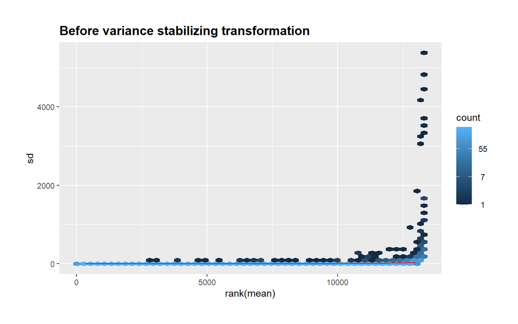

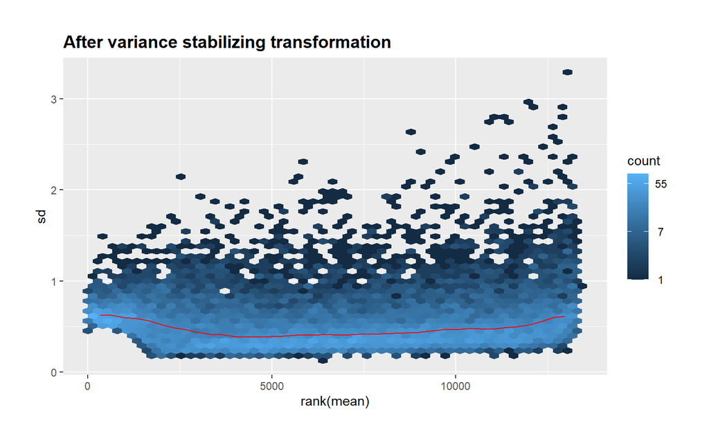

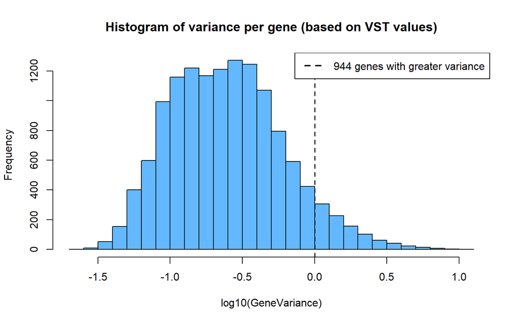

```r
library("DESeq2")
library("vsn")
library("ggplot2")

### Exploring variance in the data set

## While the values in dataFilt_Coding are quantile normalized (see first section)
# I wanted to see if they were variance stabilized, which seems like it might
# help unearth more patterns through PCA, as this is a variance based technique.
# It turned out that they are not, so the variance stabilizing transformation was used:
vsn_values <- varianceStabilizingTransformation(dataFilt_Coding)

## Visualize normalization by boxplots for all samples before and after normalization
meanSdPlot(dataFilt_Coding)$gg + ggtitle("Before variance stabilizing transformation") + theme(plot.title = element_text(size = 14, face = "bold")) + theme(plot.margin = unit(c(1,1,1,1), "cm"))
meanSdPlot(vsn_values)$gg + ggtitle("After variance stabilizing transformation") + theme(plot.title = element_text(size = 14, face = "bold")) + theme(plot.margin = unit(c(1,1,1,1), "cm"))

## Using the histogram of variance to find a suitable variance threshold based on the distribution at hand
var.cutoff <- 10^0 # somewhat arbitrarily played around with this based on the histogram
gene_variances <- apply(vsn_values, MARGIN = 1, var)
hist(log10(gene_variances), xlab="log10(GeneVariance)", main="Histogram of variance per gene (based on VST values)", col="steelblue1", breaks=20)
abline(v=log10(var.cutoff), lty=2, lwd=1.5)
legend(x="topright", legend=c(paste(sum(gene_variances>var.cutoff), "genes with greater variance")), lty=2, lwd=2)
```

As seen above, the variance stabilizing transformation (VST) did what it is supposed to (compare first and second plots above). Some caveats behind my use of the VST and my rationale for using it were discussed earlier and will be discussed again in more detail in the PCA section. The histogram of variance throughout the variance-stabilized values for all genes is directly above. Choosing the top ~944 genes selects for what I see as most of the high-variance tail of the distribution. When conducting PCA, I usually do not favor aggressively filtering by variance (e.g. only taking the top 50 variance genes). Due to how PCA works, I trust that it will tease out the dominant variance patterns such that aggressive variance filtering does not seem necessary. Furthermore, if other patterns exist among moderately high variance genes in addition to the dominant/strongest features, I want to make sure they have a change of being included (even though they will likely often be overshadowed by dominant effects). This is the rationale behind my variance cutoff above, but as discussed earlier, this step and PCA were a bit of an cyclical trial-and-error process (adjust the filter, see what happens).

It is important to explore variance prior to model building because any predictive model will often be based on higher-than-average variance variables (here genes). Thus, when model building, we will typically be much more interested in including the highest variance features/predictors than including the lowest variance ones. In the extreme case, if a gene does not change at all between the samples (including those grouped by labels we are trying to predict), then that gene provides no information or predictive value to the model (how could it!). There are of course “in between” cases, for example, a gene could be expressed differently between two sample groups in an *extremely consistent* way, but such a gene may not have particularly extreme overall variance. That said, it is the genes/variables that do vary quite a bit that are more likely to vary systematically between various groups of samples (including the groups we care to predict). Variance exploration and variance-based filtering of features provides a way to find potentially relevant features without explicitly seeking them out. Also, if all the genes in a data set have pretty low and tightly distributed variance, then this may indicate that the data set does not have much (if any) value for building a predictive model. I would add that a differential expression analysis is similar to variance-based gene filtering in that it essentially aims to identify those genes that change (i.e. vary). A major difference is that DEGs have been explicitly sought out for varying *along the lines of a distinction of interest*. So the genes from a differential expression analysis have been identified via a more biased technique, which may be more appropriate depending on the goal and context. “Blind” variance-based filtering is ideal prior to PCA because we typically want to use PCA to explore the dominant patterns in the data (unsupervised), rather than seek out a pattern we already expect. In other words we are aiming to let the *data* tell us whether it might support building a certain predictive model before actually trying to build one.

## Principal component analysis

In the code below, PCA is first run on the VST values of the top 1000 variance genes using `prcomp()`. This cutoff was based on the analysis/rationale discussed in the previous section. Next, a function was re-purposed from one of my previous homework submissions which makes 3 plots of the samples using pairs of the top 3 principal components, along with the bar chart of variance explained by the principal components (returned when running `plot()` on an object produced by `prcomp()`). This function is then called within a loop, which, with the help of another function `colors.by.group()`, is then used to create the same 4 plots of PCA results per categorical variable considered in the previous sections. In each plot, the labels of the categorical variable have been mapped to different colors. This loop and the functions involved also handle the fact that many labels are missing, and samples with missing values are always colored black for each categorical variable. Making these plots enabled me to quickly look through the PCA results for any clusters that appear to occur along the lines of categorical patient metadata (i.e. could well-defined clusters be identified for a given label?). It should be noted that the code chunk seen below was not actually run when Knitting the R Markdown file. Again, two separate hidden chunks were used, the latter of which puts the results of the for loop into separate tabs for less chaotic viewing (there were many categorical variables).

```r
library("pals")


## Run PCA using the top variance genes (as determined by exploration of variance)
n.top.vars <- 1000 # This is based on the earlier observation that 1000ish seems decent
PCA.top.var <- prcomp(t(vsn_values[rank(-gene_variances)<=n.top.vars,,drop=FALSE]), scale=TRUE)


## Visualize the results of the PCA with different categorical labels

# Function used to map sample IDs to their respective colors based on their label for the current variable
colors.by.group <- function(sample.IDs, default=alphabet(26)[5]) {as.character(sapply(patient.meta[sample.IDs, categorical.col.c], function(label) ifelse(is.na(label), default, group.colors[label])))}

# Function modified from earlier homework to plot samples in planes made by the top 3 components
generate.pc.plots <- function(PCA.obj, descriptor, legend.pos=list(title="title", which.plot=1, location="topright", scale=1)) {
  # Make plots in the coordinate planes of the top three principle components
  par(mfrow=c(2,2))
  prcomps <- list(c("PC1", "PC2"),
                  c("PC1", "PC3"),
                  c("PC2", "PC3"))
  missing.col <- alphabet(26)[5]
  sample.colors <- colors.by.group(rownames(PCA.obj$x), default = missing.col)
  # Loop through combinations of PCs to plot the samples in
  for (i in 1:length(prcomps)) {
    x <- prcomps[[i]][1]
    y <- prcomps[[i]][2]
    plot(PCA.obj$x[,x], PCA.obj$x[,y],
         pch=19,
         col=sample.colors,
         xlab=x,
         ylab=y,
         main=paste(y, " vs ", x, "\n(", descriptor,")", sep="")[[1]])
    make.legend <- function() {
      legend(x=legend.pos$location, cex=legend.pos$scale,
             legend=c(names(group.colors), "NA"),
             col=c(group.colors, missing.col),
             pch=19, title=legend.pos$title)
    }
    if (i == legend.pos$which.plot & i != 4) {
      make.legend()
    }
  }
  # Add the bar plot of variance captured by each principle component in the 4th pane
  plot(PCA.obj, main="Top principle components by variance\n(leftmost = PC1)", col="lightgreen")
  if (legend.pos$which.plot == 4) {
    make.legend()
  }
  par(mfrow=c(1,1))
}

# This variable has Booleans, which makes things more complicated so convert it to strings
patient.meta$is_ffpe <- ifelse(patient.meta$is_ffpe, "true", "false")

# Loop through each categorical variable and color points of PCA plots accordingly
for (i in 1:length(cat.vars)) {
  # Prepare the group label colors for the current metadata variable
  categorical.col.c <- cat.vars[i]
  n.labels <- length(table(patient.meta[,categorical.col.c]))
  group.colors <- alphabet()[-c(4,5)][1:n.labels]
  names(group.colors) <- as.character(levels(as.factor(patient.meta[,categorical.col.c])))
  # Call the convenience function to make plot with the current metadata coloring scheme
  cust.scale <- if (cat.vars[i] %in% c("primary_diagnosis", "ajcc_pathologic_n", "morphology")) {0.8} else {0.95}
  generate.pc.plots(PCA.top.var,
                    descriptor=paste("top", n.top.vars, "variance genes")[[1]],
                    legend.pos=list(title=cat.vars[i],
                                    which.plot=4,
                                    location="topright",
                                    scale=cust.scale))
}
```

#### PCA results colored by categorical variable (click variable name to see plot)

##### sample_type

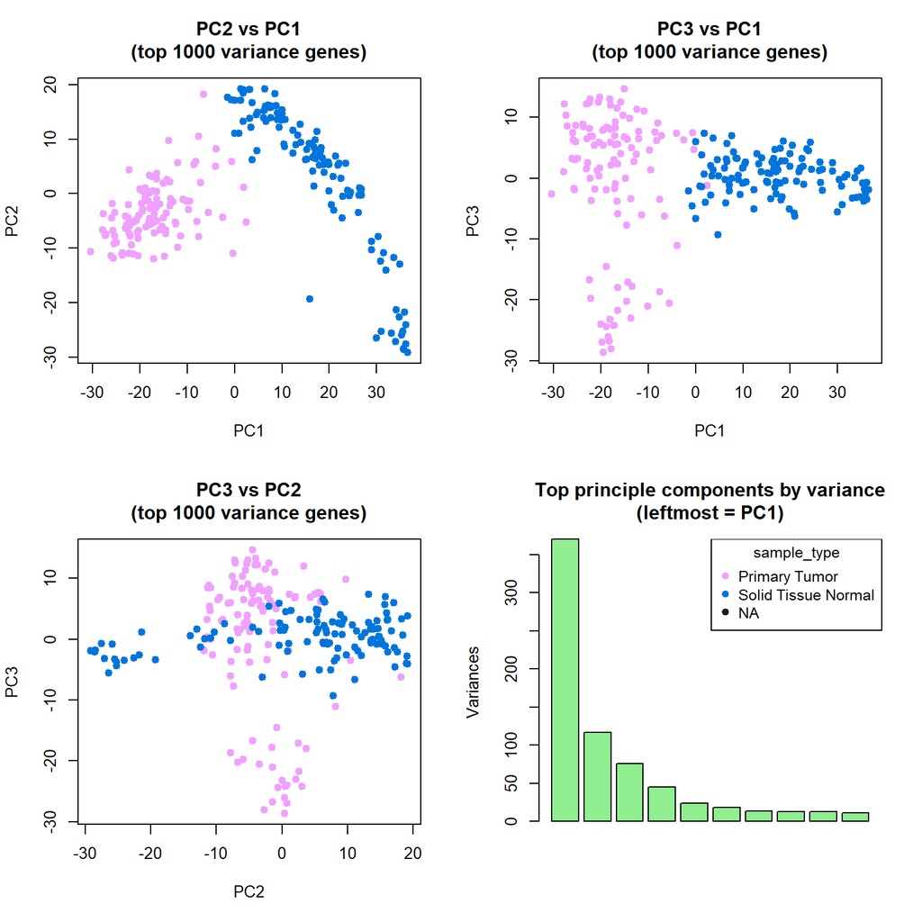

##### preservation_method

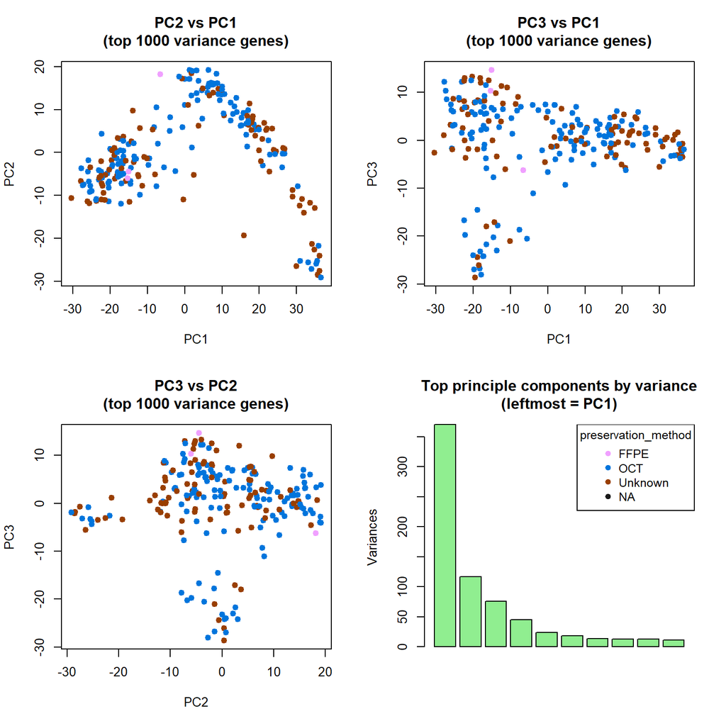

##### oct_embedded

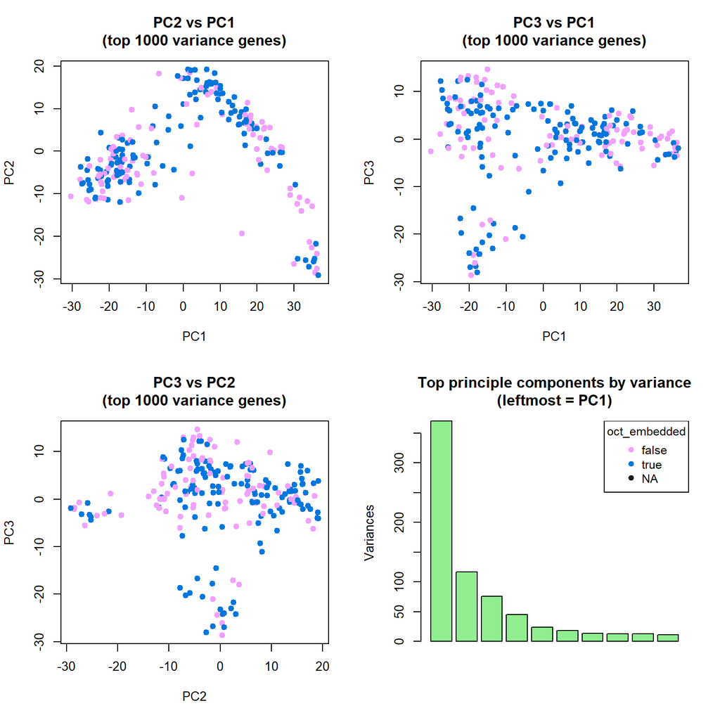

##### is_ffpe

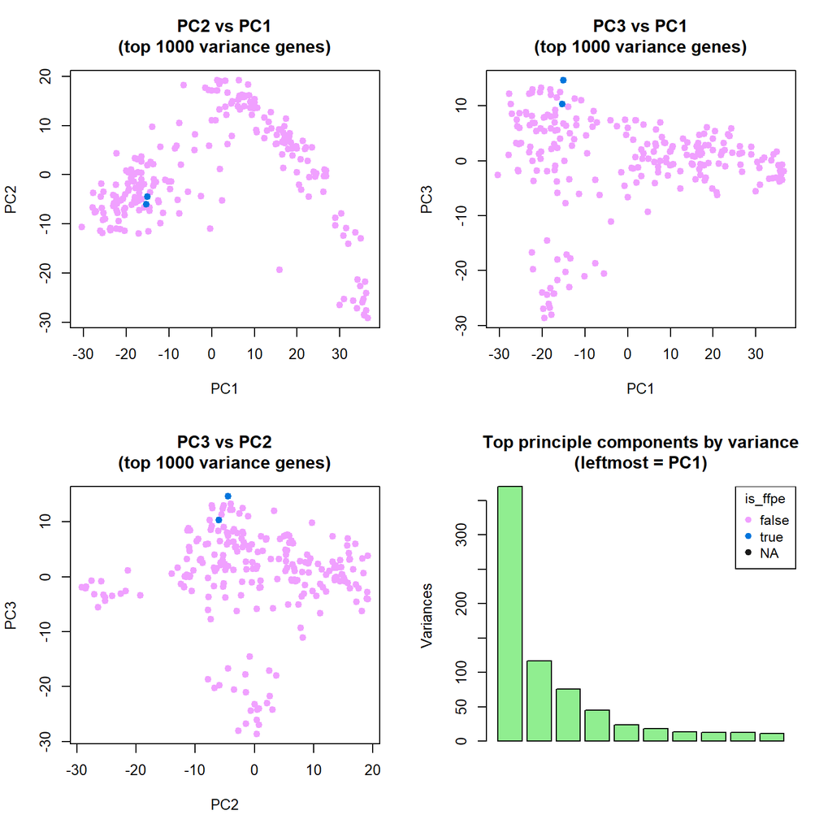

##### synchronous_malignancy

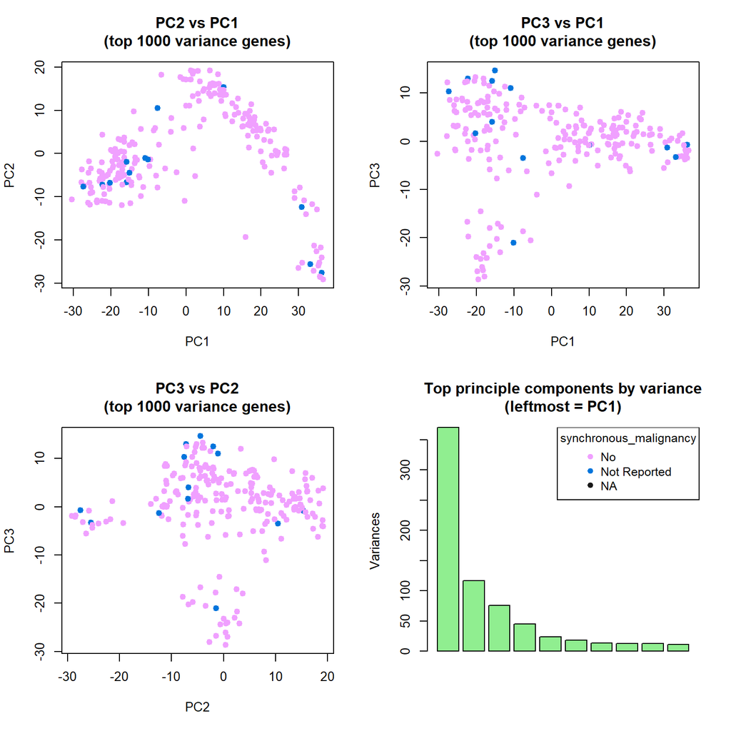

##### ajcc_pathologic_stage

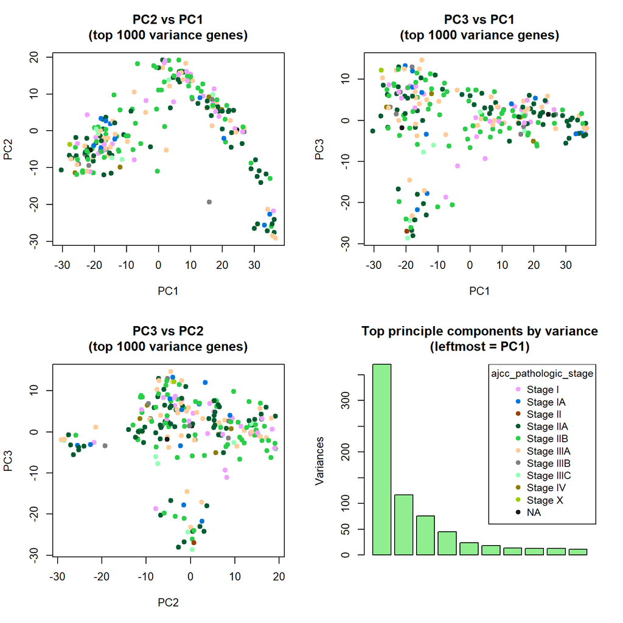

##### tissue_or_organ_of_origin

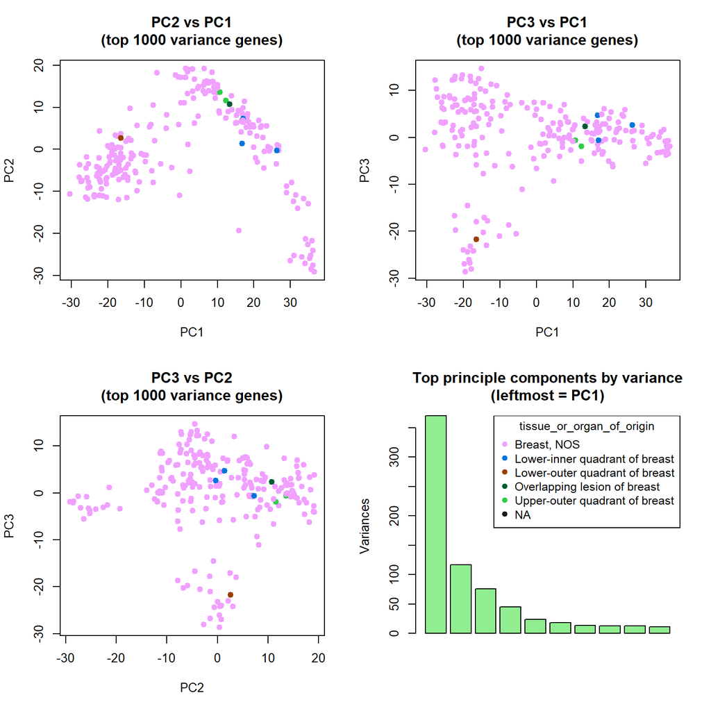

##### primary_diagnosis

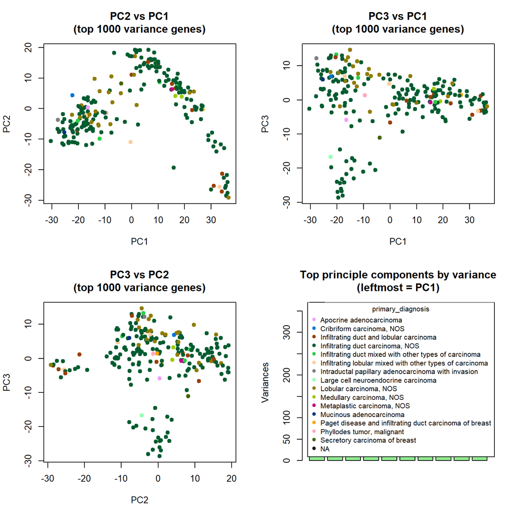

##### prior_malignancy

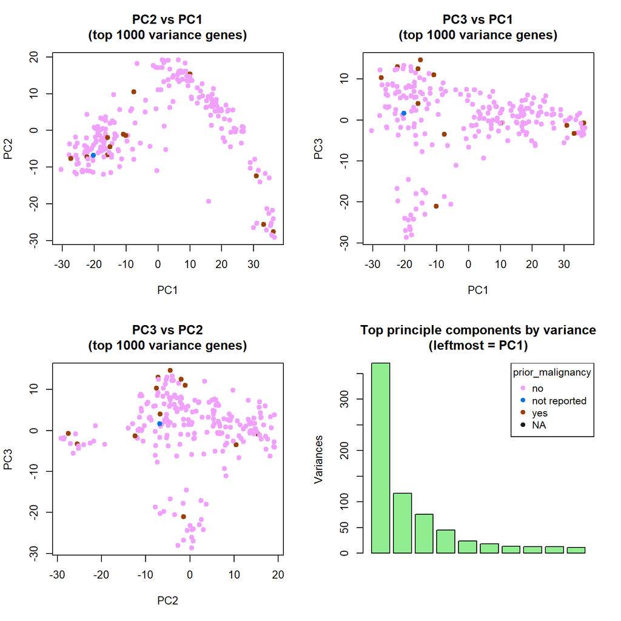

##### prior_treatment

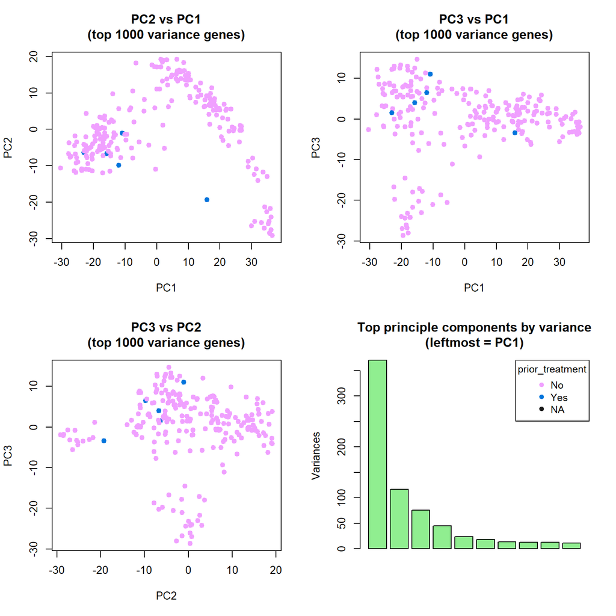

##### ajcc_staging_system_edition

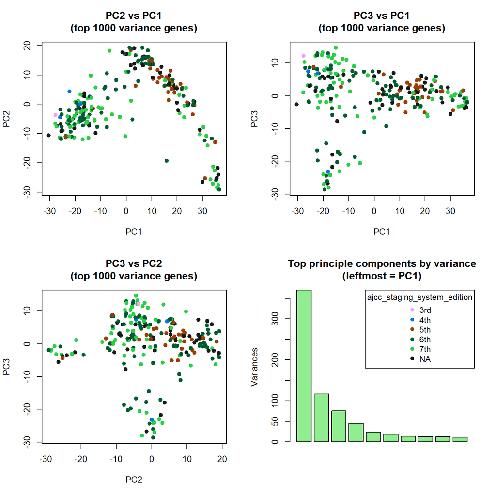

##### ajcc_pathologic_t

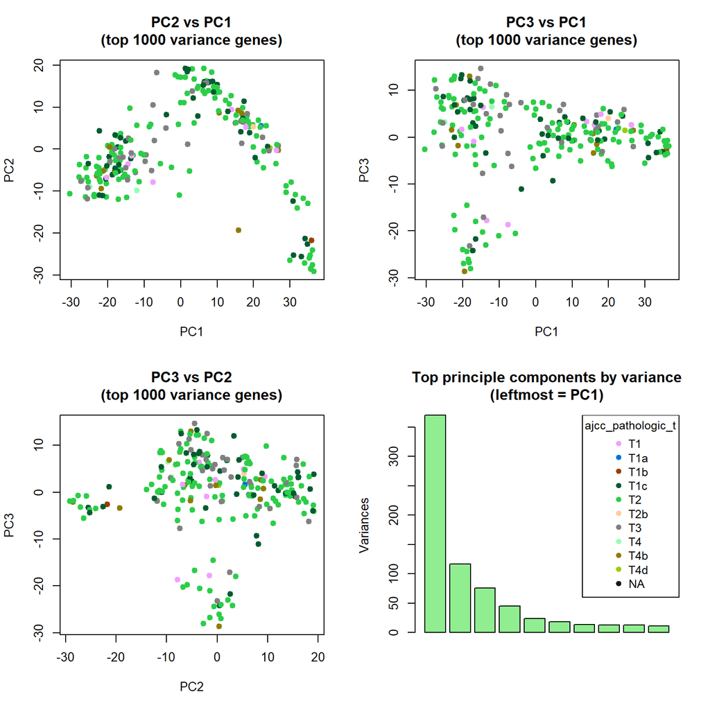

##### ajcc_pathologic_n

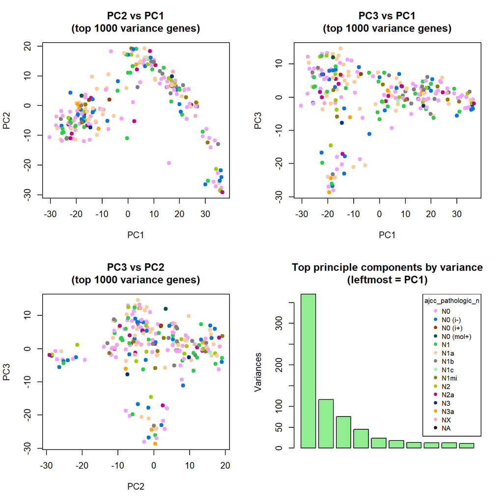

##### ajcc_pathologic_m

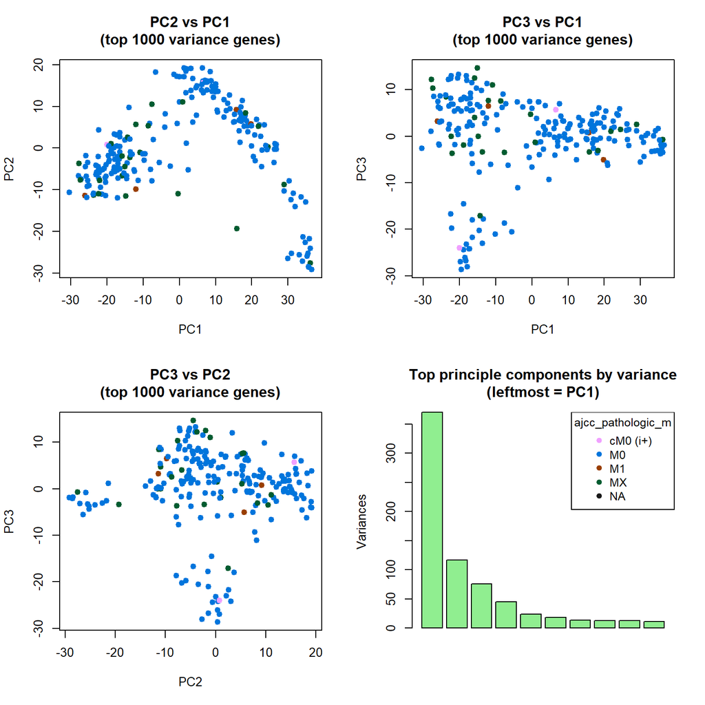

##### morphology

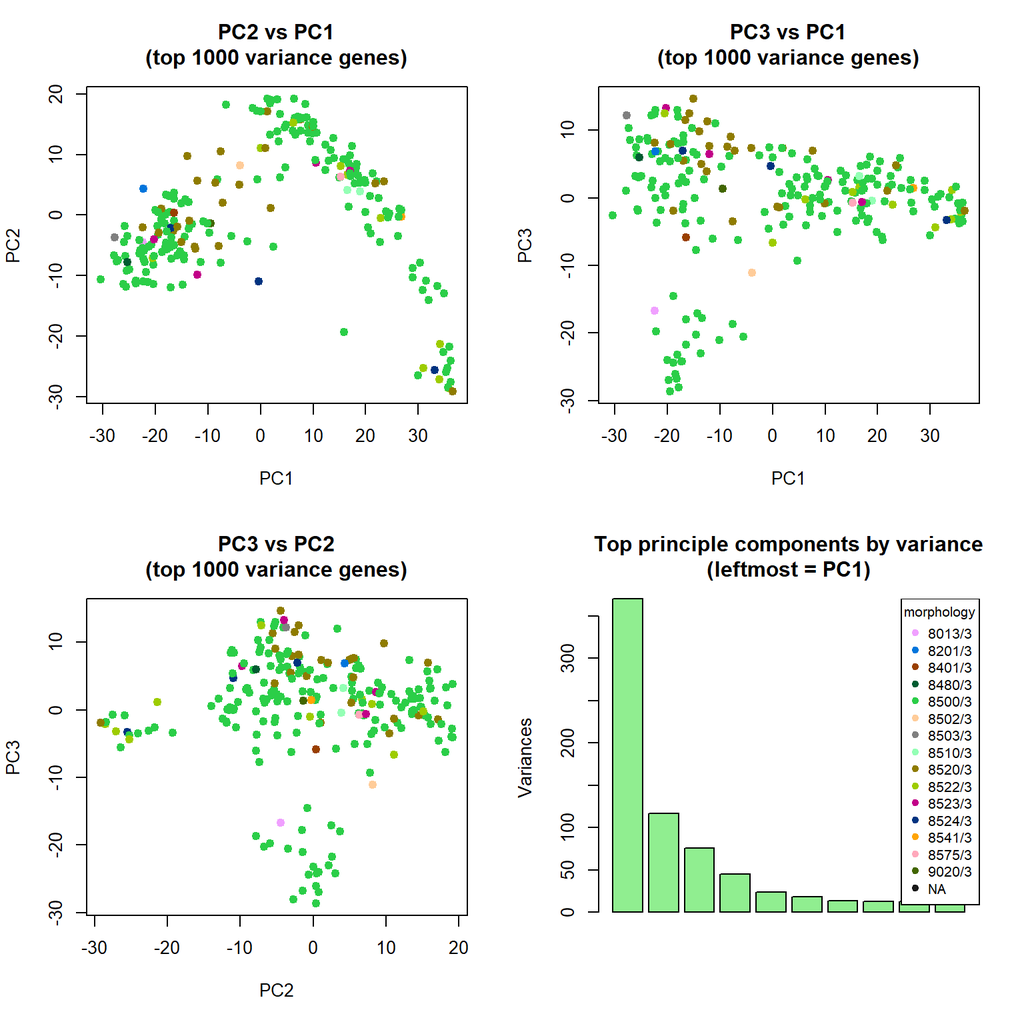